# SIR Model With Testing Flows and Isolation

Ali

15/08/2020

Notes on other references: (1) testing_flow.md(I am using the notation in this doc)

# On Math and Weighting

## Model and Definitions

- Assume there are 3 groups of individuals: $S$, $I$ and $R$.
- Each group splits into 4 subgroups to incorporate the testing mechanism, so overall the model framework has 12 compartments as follows. $S_u,$ $S_n$, $S_p$, $S_t$, $I_u$, $I_n$, $I_p$, $I_t$, $R_u$, $R_n$, $R_p$, $R_t$.
- Further, assume that (1) a perfectly specific test, i.e. no false positives, then $S_p$ and $S_t$ are always zero (2) there are two ‘integrator’ or ‘accumulator’ compartments, $N$ and $P$, to collect cumulative reported negative or positive tests.

## Per Capita Rate of Flow from Untested to Positive or Negative Compartments

- $t$: testing intensity with dimension of $1/time$.
- $\omega$: the rate of *onward flow* from the awaiting positive compartment, $p$, to reported/tested compartment, $t$, or from awaiting negative compartment, $n$, back to $u$. It has units of $1/time$.
- Note: The complicated part is the flow rate from $Z_u$ to $Z_n$, $Z_p$. The (total, not per capita) flow from $Z_u$ to $Z_n$ is $t (1-P_Z) F(W_Z) Z_u$, from $Z_u$ to $Z_p$ is $t P_Z F(W_Z) Z_u$. Where, $P_Z$ is the probability of positive test.
- At the simplest $F(W_Z)=W_Z$. The flows from $Z_n$ to $Z_u$ and $Z_p$ to $Z_t$ are $\omega Z_n$ and $\omega Z_p$ respectively. We are using a dimensionless scaling where $F(W_Z) = (W_Z \cdot N_0)/\sum_{Z'} \left( W_{Z'} {Z'}_{u} \right)$, i.e. the denominator is the sum of the product of the weights and the current occupancy of the untested compartments.

## Model

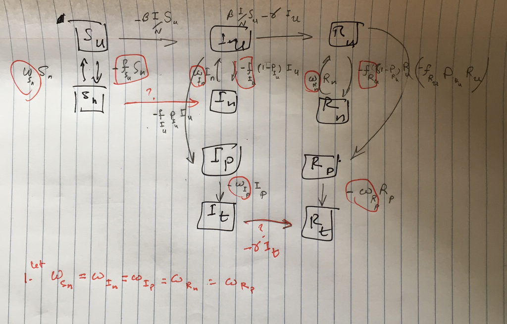

Let the force of infection $\Lambda=\beta \frac{(I_u+\eta_w I_n+\eta_w I_p+ \eta_t I_t)}{N_0}$, where $\eta$ is the isolation parameter with the following assumptions:

1. All susceptible individuals are exposed to all infectious individuals regardless of the group factor.
2. $\eta_t<\eta_w$, i.e., the awaiting individuals for test results have higher transmission probability than the reported individuals.
3. The scaling parameter is defined as $sc = t N_0/(W_s S_u + W_i I_u + W_r R_u)$ and $F_s = sc \times W_s$, $F_i=sc \times W_i$ and $F_r = sc\times W_r$.

The model is
$$\begin{align}
\label{mod:1}
1)\ d S_u/dt &= -\Lambda S_u - F_s S_u + \omega S_n \\
2)\ d S_n/dt &= -\Lambda S_n + F_s S_u - \omega S_n \\
3)\ d I_u/dt &= \Lambda S_u - F_i I_u + \omega I_n - \gamma I_u \\
4)\ d I_n/dt &= \Lambda S_n + (1-P_i) F_i I_u - \omega I_n -\gamma I_n \\
5)\ d I_p/dt &= P_i F_i I_u - \omega I_p -\gamma I_p \\
6)\ d I_t/dt &= \omega I_p - \gamma I_t \\
7)\ d R_u/dt &= \gamma I_u - F_r R_u + \omega R_n \\
8)\ d R_n/dt &= \gamma I_n + (1-P_r) F_r R_u - \omega R_n \\
9)\ d R_p/dt &= \gamma I_p + P_r F_r R_u - \omega R_p \\
10)\ d R_t/dt&= \gamma I_t + \omega R_p \\
11)\ dN/dt &= \omega (S_n + I_n + R_n) \\
12)\ dP/dt &= \omega(I_p + R_p).
\end{align}$$

```r
library(deSolve)
library(ggplot2)
library(tidyr)
library(McMasterPandemic)
library(directlabels)
unpack <- McMasterPandemic::unpack
```

```r
sir.model <- function(time,state,params){
    unpack(as.list(c(state,params)))
    ## Force of Infection
    Lambda <- beta * (I_u + eta_w*(I_n+I_p) + eta_t*I_t)/N0
    ## scaling the weights
    sc <- t*N0/(W_s*S_u+W_i*I_u+W_r*R_u)
    # sc <- t*N0
    F_s <- sc*W_s
    F_i <- sc*W_i
    F_r <- sc*W_r

    dS_u.dt <- -Lambda*S_u - (1-P_s) * F_s * S_u + omega * S_n
    dS_n.dt <- -Lambda*S_n + (1-P_s) * F_s * S_u - omega * S_n
    dI_u.dt <-  Lambda*S_u + omega * I_n - F_i * I_u - gamma * I_u
    dI_n.dt <-  Lambda*S_n + (1-P_i) * F_i * I_u  - omega * I_n - gamma * I_n
    dI_p.dt <-  P_i * F_i * I_u - omega * I_p - gamma * I_p
    dI_t.dt <-  omega * I_p - gamma * I_t
    dR_u.dt <- gamma * I_u + omega * R_n - F_r * R_u
    dR_n.dt <- gamma * I_n + (1-P_r) * F_r * R_u - omega * R_n
    dR_p.dt <- gamma * I_p + P_r * F_r * R_u - omega * R_p
    dR_t.dt <- gamma * I_t + omega * R_p
    dN.dt <- omega * (S_n + I_n + R_n)
    dP.dt <- omega *(I_p + R_p)

    # return the rate of change
  dxdt <- c(dS_u.dt,dS_n.dt,dI_u.dt,dI_n.dt,dI_p.dt,dI_t.dt,dR_u.dt,dR_n.dt,dR_p.dt,dR_t.dt,dN.dt,dP.dt)
    ## }
    return(list(dxdt))
}
```

```r
params <- c(N0=1000000, beta=1,gamma=1/3, omega=0.25, t=0.01,
             W_s=0.01, W_i=1, W_r=0.01, #weights
             P_s=0, P_i=0.5, P_r=0.5, #prob of waiting for being tested positive
            eta_w=0.02, eta_t=0.01 #isolation parameter
            )
class(params) <- "params_pansim"
state_init <- c(S_u=params[["N0"]], S_n=0,
                I_u=1,I_n=0,I_p=0,I_t=0,
                R_u=0,R_n=0,R_p=0,R_t=0,
                N=0,P=0)
# Disease free equilibrium
Sn_dfe <-function(params){
  unpack(as.list(params))
  return((t*(1-P_s)*N0)/omega)
}
Su_dfe<- params[["N0"]]-Sn_dfe(params)

state_dfe <- c(S_u=Su_dfe, S_n=Sn_dfe(params),
                I_u=0,I_n=0,I_p=0,I_t=0,
                R_u=0,R_n=0,R_p=0,R_t=0,
                N=0,P=0)

d <- seq(0,200,by=0.1)
# Conditional stop for desolver
rootfun <- function (time, state,params) {
  unpack(as.list(c(state,params)))
  return(I_u - 1) }
```

Test gradient

```r
g1 <- sir.model(time=0,state=state_init, params=params)
all.equal(sum(g1[[1]]),0)
```

```
## [1] TRUE
```

```r
## debug(sir.model)
## g1 <- sir.model(time=0,state=state_init, params=params)
```

```r
out <- as.data.frame(
  ode(
    func=sir.model,
    y=state_init,
    times= d,
    parms=update(params,beta=2),
    # atol = 1e+1, rtol = 1e+1
    # rootfun = rootfun,
    # method="lsodar"
  )
)

out2 <- out %>%
  pivot_longer(c(S_u,S_n,I_u,I_n,I_p,I_t, R_u,R_n,R_p,R_t), names_to = "compartment", values_to = "value")
```

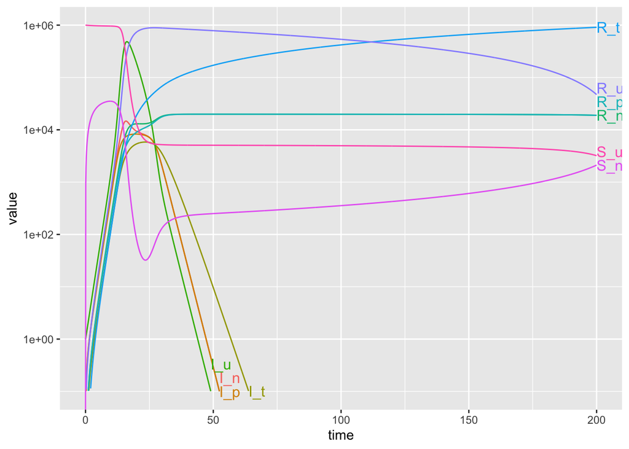

```r
gg1 <- (ggplot(data=out2, aes(x=time,y=value,col=compartment))
    + geom_line()
    + scale_y_log10(limits=c(0.1,params[["N0"]]))
##    + scale_x_continuous(limits=c(0,240))
)
direct.label(gg1,"last.bumpup")
```

```r
d_long <- seq(0,300,by=0.1)
## capturing badly behaved integrator warning messages
cc <- capture.output(
    out_long <- as.data.frame(
        ode(
    func=sir.model,
    y=state_init,
    times= d_long,
    parms=update(params,beta=2)
    # rootfun = rootfun,
    # method="lsodar"
  )
  ))
out_long2 <- out_long %>%
    pivot_longer(c(S_u,S_n,I_u,I_n,I_p,I_t, R_u,R_n,R_p,R_t),
                 names_to = "compartment", values_to = "value")
```

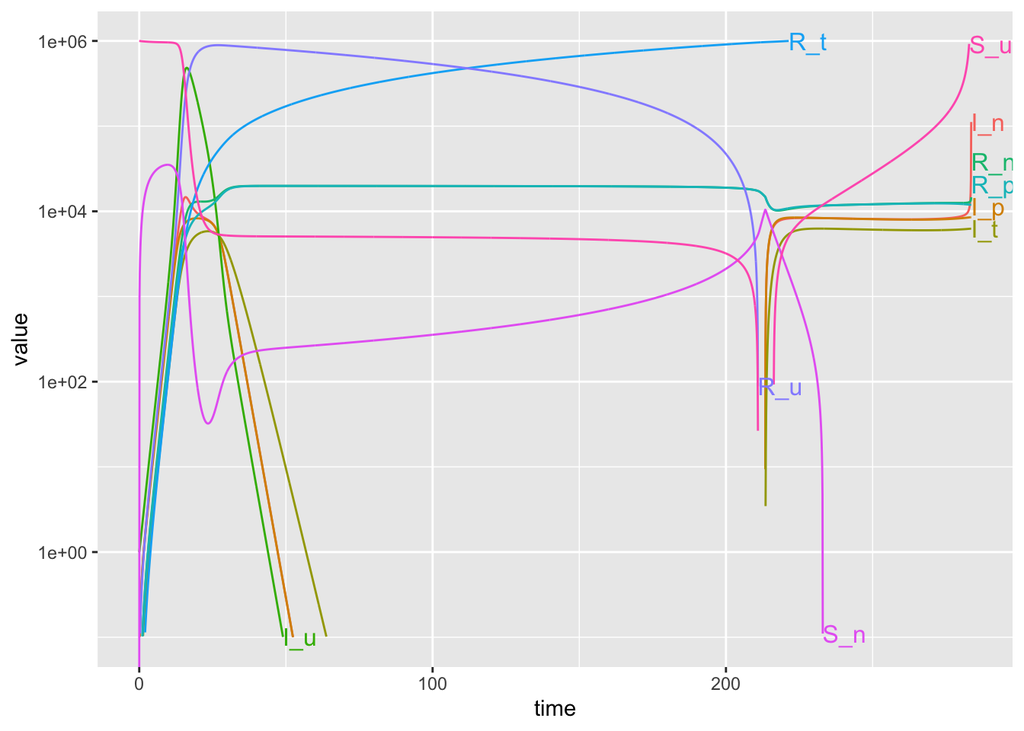

```r
direct.label(gg1 %+% out_long2,"last.bumpup")
```

### Steady States

The Disease-Free Equilibrium, namely $E_1$, for the above SIR model is $S_n^*= \frac{t (1-P_s)}{\omega} N_0, S_u^*= N_0-S_n^*$, and $I_j=R_j=0 \ \forall j$.

### Basic Reproduction Number

$$R_0= (A \times S_u^* + B \times S_n^*) \times C,$$
where $A=\gamma(\omega+\gamma) + (\gamma \eta_w + \omega \eta_t P_i) F_i$, $B=\big(\omega+(F_i+\gamma)\eta_w\big) \gamma+\frac{(\eta_w \gamma+ \eta_t\omega) \omega P_i F_i }{\omega+\gamma}$ and $C=\frac{\beta/\gamma}{N_0 (\gamma(\omega+\gamma)+F_i(\gamma+\omega P_i))}$.

$$\begin{equation}\label{FV}
F= \beta/N_0 \left[ \begin {array}{cccc}
S_u&\eta_w\,S_u&\eta_w\,S_u&\eta_t\,S_u\\
S_n&\eta_w\,S_n&\eta_w\,S_n&\eta_t\,S_n\\
0&0&0&0\\
0&0&0&0
\end {array} \right],
V=
\left[ \begin {array}{cccc}
F_i+\gamma&-\omega&0&0\\
-(1-P_i)F_i&\omega+\gamma&0&0\\
-P_i F_i&0&\omega+\gamma&0\\
0&0&-\omega&\gamma
\end {array} \right],
\end{equation}$$

$$\begin{equation}
G = \left[ \begin {array}{cc}
G_{11}&G_{12}\\
0&0
\end {array} \right], \text{ where } \\
G_{11} =C
\left[\begin {array}{cc}
A\,S_u & B\,S_u\\
A\,S_n & B\,S_n
\end {array}\right],
\end{equation}$$

The Eigenvalues of $G_{11}$, are 0 and $R_0$.

```r
F_i <- function(state,params){
   unpack(as.list(c(state,params)))
   return(t*N0*W_i/(W_s*S_u+W_i*I_u+W_r*R_u))
 }
 # just a test
  F_i(state=state_dfe,params=update(params,t=0))
```

```
## [1] 0
```

```r
R0<-function(params){
    unpack(as.list(params))
    Sn_dfe<- Sn_dfe(params)
    Su_dfe<- N0-Sn_dfe
    F_i <-t*N0*W_i/(W_s*Su_dfe) #at DFE
    # F_i <-t*N0*W_i
    A <-gamma*(omega+gamma+eta_w*F_i) + omega*eta_t*P_i*F_i
    B <-(omega+eta_w*(F_i+gamma))*gamma+(eta_w*gamma+eta_t*omega)*(omega*P_i*F_i)/(omega+gamma)

    C <- beta/(N0*gamma*(gamma*(omega+gamma)+F_i*(gamma+omega*P_i)))
    return((A*Su_dfe+B*Sn_dfe)*C)
}

# R0<1:
R0(params=params)
```

```
## [1] 0.8857236
```

```r
# R0>1:
R0(params=update(params,beta=2))
```

```
## [1] 1.771447
```

Can we recover $R_0=\beta/\gamma$ of the simple SIR? -yes

```r
# checking if simple R_0 for SIR can be recovered?
# Case #1: t=0
all.equal(R0(params=update(params,t=0)), params[["beta"]]/params[["gamma"]])
```

```
## [1] TRUE
```

```r
# Case #2:
all.equal(R0(params=update(params,eta_t=1,eta_w=1)), params[["beta"]]/params[["gamma"]])
```

```
## [1] TRUE
```

### On Behaviour of Testing at DFE Boundry

1. Note that once the only untested people are susceptibles, the FoI will be $\Lambda=0$, testing rate $F_s=t N_0/S_u$. Thus, eq(1) of the model will be $d S_u/dt = - t N_0 + \omega S_n$ which is a linear rate of leaving the $S_u$ compartment. That means that the testing rate will be no longer dependent on $S_u$.

### Contour plot of $R_0=1$ and interpretations

```r
 # specify the ranges
 beta  <- 0.8  ## set beta high enough to allow R0>1 in worst case
 eta_w <- seq(0,1, length.out=5)
 eta_t <- seq(0,1, length.out=5)
 t     <- seq(0,0.01, length.out=20)
 omega <- seq(0.1,1 , length.out=20) #note omega must be > t


 df1 <- expand.grid(N0=params[["N0"]],beta=beta,gamma=params[["gamma"]],omega=omega,t=t,
                    W_s=params[["W_s"]],W_i=params[["W_i"]],W_r=params[["W_r"]],
                    P_s=params[["P_s"]],P_i=params[["P_i"]],P_r=params[["P_r"]],
                    eta_w=eta_w,eta_t=eta_t)

df2<- data.frame(df1,R0=apply(df1,1,function(params_in)R0(params=params_in)),
                      Fi= apply(df1,1,function(params_in)F_i(state=state_dfe,params=params_in)))

which(df2[]<0)
```

```
## integer(0)
```

```r
## hacked (not very robustly) to chain label_both() and label_parsed() ...
label_special <- function (labels, multi_line=FALSE, sep = "== ") {
    value <- ggplot2:::label_value(labels, multi_line = multi_line)
    variable <- ggplot2:::label_variable(labels, multi_line = multi_line)
    variable[[1]] <- gsub("_(.)$","[\\1]",variable[[1]])
    ## not using multiple faceting variables on each margin, so forget paste
    out <- Map(paste, variable, value, sep = sep)
    out[[1]] <- lapply(out[[1]], function(expr) c(parse(text=expr)))
    out
}
```

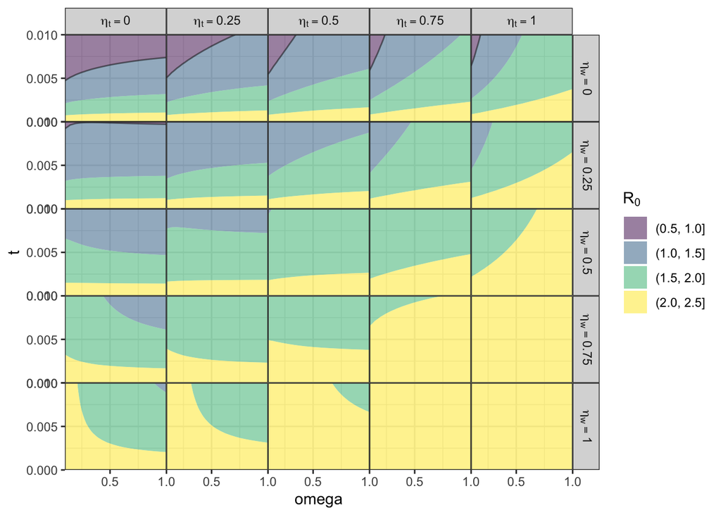

```r
p1 <- ggplot(df2,aes(x=omega,y=t,z=R0))+ theme_bw() +
    theme(panel.spacing=grid::unit(0,"lines"))
(p1
    + geom_contour_filled(breaks=pretty(unique(df2$R0),5),
                          alpha=0.5) ## breaks=0.2)
    + geom_contour(breaks=1,alpha=0.5,colour="black")
    + facet_grid(eta_w~eta_t, labeller=label_special)
    + scale_x_continuous(expand=expansion(c(0,0)), n.breaks=3)
    + scale_y_continuous(expand=expansion(c(0,0)), n.breaks=3)
    + scale_fill_viridis_d(name=parse(text="R[0]"))
)
```

Let call the $F_i$ the critical testing rate in the above plot.

**Propositions**

1. $\partial{R_0}/\partial{\eta_t} \geq 0$ and $\partial{R_0}/\partial{\eta_w} \geq 0$.
2. $\partial{R_0}/\partial{t} \leq 0$; this is concluded from the Taylor expansion of $R_0$ around $t=0$ which is $R_0 \approx \beta/\gamma + \frac{\beta t}{\omega (\omega+\gamma) \gamma^2 W_s} \Big(\gamma(\eta_w-1)(\gamma W_s+\omega W_i) + (\eta_t -1)P_iW_i \omega^2 \Big) + \mathcal{O}(t^2)$.
3. Based on the above Taylor expansion around $t=0$,
   $$\partial{R_0}/\partial{\omega}= \frac{-\beta t}{\gamma W_s\omega^2 (\gamma+\omega)^2} (a \omega^2 + b \omega + c),$$
   where $a=(\eta_w-1)W_i-(\eta_t-1)P_iW_i$, $b=2(\eta_w-1)\gamma W_s$ and $c=(\eta_w-1)\gamma^2 W_s$. Given that $\eta_t\leq \eta_w$, it is inferred that $a\geq 0$, $b\leq 0$ and $c \leq 0$. Let $\omega_1<0$ and $\omega_2>0$ be the roots of the quadratic expression in $\partial{R_0}/\partial{\omega}$. Thus, $\partial{R_0}/\partial{\omega}<0$ for $0<\omega<\omega_2$ and $\partial{R_0}/\partial{\omega}>0$ for $\omega>\omega_2$.